# Chicago Bikeshare Analysis - Divvy Bike Usage in the City of Chicago

Markisha (Misha) Berrien

2/17/2019

[figure not shown]

```r
# Makes list of first bike check-out of each station. This gives opening date of each station
# Source: https://stackoverflow.com/questions/19944334/extract-rows-for-the-first-occurrence-of-a-variable-in-a-data-frame

station_dates <-
  divvy[match(unique(divvy$TO.STATION.ID), divvy$TO.STATION.ID),] %>%
  select(TO.STATION.ID, STOP.TIME)

station_dates <-
  station_dates %>%
  arrange(STOP.TIME) %>%
  mutate(year = year(STOP.TIME),
         month = month(STOP.TIME),
         day = day(STOP.TIME),
         OPENING.DATE = as.Date(paste(year, month, day, sep='-'))) %>%
#  rename("STATION.ID" = "TO.STATION.ID") %>%
  select(TO.STATION.ID, OPENING.DATE)

# Join opening date information to divvy_station dataframe
divvy_opening <-
  divvy_stations %>%
  left_join(station_dates, by = c("ID" = "TO.STATION.ID")) %>%
  mutate(OPENING.YEAR = year(OPENING.DATE)) %>%
  filter(!is.na(OPENING.YEAR))

# Filter Evanston Points
divvy_opening_sub <-
  divvy_opening %>%
  filter(!Latitude >= 42.02346)

# End Map
ggplot() +
  geom_sf(data = chicago_map, fill = "#CCCCCC", col = "white") +
  geom_point(data = divvy_opening_sub, aes(Longitude, Latitude, color = factor(OPENING.YEAR)), size = 0.3) +
  theme(axis.title.y = element_blank(),
    axis.title.x = element_blank(),
    axis.text.x = element_blank(),
    axis.text.y = element_blank(),
    axis.ticks = element_blank(),
    text = element_text(family = "SourceSerifPro-Regular", face = "bold",
                              colour = "black", size = 11,
                              hjust = 0.5, vjust = 1, angle = 0,
                              lineheight = 0.9),
    rect = element_blank(),
    plot.title = element_text(size=13, face="bold",
    margin = margin(10, 0, 10, 0))) + # Remove map gridlines
  labs(color = "Years",
    title = "Divvy bike stations opened first in West, Southwest and South Chicago \nand later expanded to Chicago's Northern and Southern regions",
    subtitle = "By the end of 2013, Divvy opened 300 stations scattered along Chicago's Far North, \nNorth, Central, West, Southwest and South sides",
    caption = "Source: Chicago Data Portal"
    ) +
  scale_color_bikeshare(palette = "map_step") +
  guides(colour = guide_legend(override.aes = list(size=6)))
```

Daily ridership ebbs and flows with the changing seasons. During the height of summer in 2016, trips reached a height of around 12,000 rides per day. During the winter months, the average daily ridership drops to below 3,000.

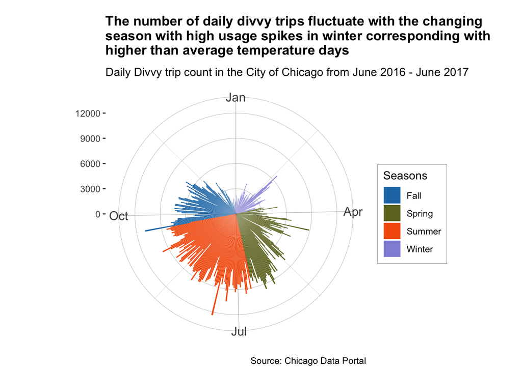

```r
#Number of bikes used per day from Summer 2016 to Summer 2017
# Source: https://medium.com/optima-blog/using-polar-coordinates-for-better-visualization-1d337b6c9dec
divvy_c %>%
  filter(!is.na(Community.Areas)) %>%
  filter(year(START.TIME) == c(2016, 2017)) %>%
  mutate(year = year(START.TIME),
         month = month(START.TIME),
         day = day(START.TIME),
         date = as.Date(paste(year, month, day, sep='-')),
         YEAR.MONTH = factor(paste(year, month, sep='-')),
         Summer = ifelse(date >= "2016-06-20" & date <= "2016-09-21" |
                           date == "2017-06-20", 1, 0),
         # Add season column
         Fall = ifelse(date >= "2016-09-21" & date <= "2016-12-20", 1, 0),
         Winter = ifelse(date >= "2016-12-21" & date <= "2017-03-19", 1, 0),
         Spring = ifelse(date >= "2017-03-20" & date <= "2017-06-19", 1, 0)) %>%
  gather(key = season, value = value, c(Summer, Fall, Winter, Spring)) %>%
  filter(value >= 1) %>%
  mutate(YEAR.MONTH = factor(YEAR.MONTH,
                             levels = c("2016-6", "2016-7", "2016-8",
                                        "2016-9", "2016-10", "2016-11",
                                        "2016-12", "2017-1", "2017-2",
                                        "2017-3", "2017-4", "2017-5", "2017-6"))) %>%
  filter(date >= "2016-06-20" & date < "2017-06-20") %>%
  group_by(date, season) %>%
  dplyr::summarise(n_trips = n()) %>%
  ggplot(aes(x = date, y = n_trips, fill = season)) +
  geom_bar(stat = "identity") +
  coord_polar(start = 9.2) +
#  scale_fill_discrete(breaks = c(Summer, Fall, Winter, Spring)) +
  scale_fill_bikeshare(palette = "dark") +
  theme(legend.background = element_rect(fill = "white", color = "black", size = 0.1),
    panel.background = element_rect(fill = "white", colour = NA),
    strip.background = element_rect(fill = "white"),
    plot.background = element_rect(colour = "white", fill = "white", size = 1),
    panel.grid = element_line(color = "black", size = 0.05),
    axis.title.y = element_blank(),
    axis.title.x = element_blank(),
    plot.title = element_text(size=13, face="bold",
    margin = margin(10, 0, 10, 0)),
    axis.text.x = element_text(size = 12)) +
  labs(title = "The number of daily divvy trips fluctuate with the changing \nseason with high usage spikes in winter corresponding with \nhigher than average temperature days",
    subtitle = "Daily Divvy trip count in the City of Chicago from June 2016 - June 2017",
    caption = "Source: Chicago Data Portal",
    fill = "Seasons")
```

Divvy users are split into three groups, single rider users, explorer pass users and annual members. Annual members are the highest percentage of riders across all Chicago Sides, but Single Ride usage is highest in the South and Southwest sides of Chicago.

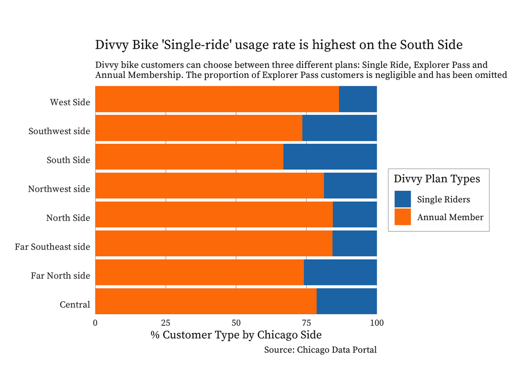

```r
#table(divvy_comp$USER.TYPE, divvy_comp$Chicago.side)

#divvy_comp$USER.TYPE <- fct_recode(divvy_comp$USER.TYPE, "Customer" = "Single Riders", "Subscriber" = #"Annual Member", "Dependent" = "24Hrs Unlimited Rides")

divvy_c %>%
  filter(!USER.TYPE == "Dependent") %>%
  mutate(USER.TYPE = fct_recode(USER.TYPE, "Single Riders" = "Customer")) %>%
  mutate(USER.TYPE = fct_recode(USER.TYPE, "Annual Member" = "Subscriber")) %>%
  group_by(USER.TYPE) %>%
  ggplot(aes(x = Chicago.side, fill = USER.TYPE)) +
  geom_bar(position = "fill") +
  coord_flip() +
  ylab("proportion") +
  bikeshare_style() +
  labs(title = "Divvy Bike 'Single-ride' usage rate is highest on the South Side",
    subtitle = "Divvy bike customers can choose between three different plans: Single Ride, Explorer Pass and \nAnnual Membership. The proportion of Explorer Pass customers is negligible and has been omitted",
    caption = "Source: Chicago Data Portal",
    y = "% Customer Type by Chicago Side",
    fill = "Divvy Plan Types") +
  scale_y_continuous(expand=c(0,0),
                     labels=c("0.00" = "0", "0.25" = "25",
                                             "0.50" = "50", "0.75" = "75", "1.00" = "100")) +
  scale_x_discrete(expand=c(0,0)) +
  scale_fill_bikeshare(palette = "two_variables") +
  theme(axis.title.y = element_blank(),
        plot.title = element_text(size=13, face="bold",
                                  margin = margin(10, 0, 10, 0)))
```

The percentage of Divvy bike trips that originate on the South Side far outstrips the areas percentage of Chicago’s population.

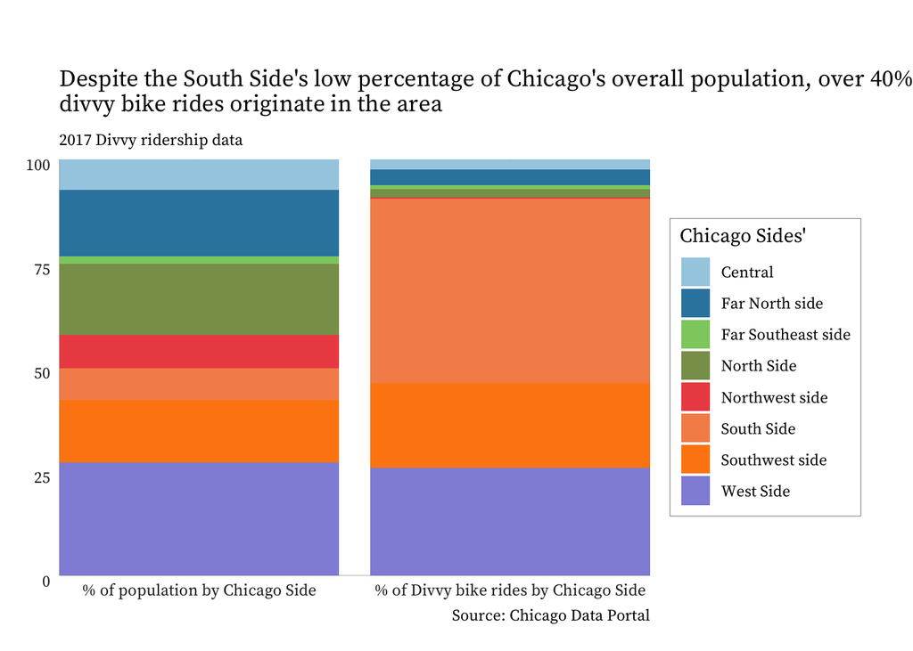

```r
#Proportion of rides per chicago side
divvy_c %>%
  filter(!is.na(Community.Areas)) %>%
  filter(year(START.TIME) == c(2017)) %>%
  group_by(Community.Areas) %>%
  dplyr::summarise(pop = unique(Total.Population),
            n_rides = n()) %>%
  left_join(chi_ca, by = "Community.Areas") %>%
  group_by(Chicago.side) %>%
  dplyr::summarise(sum_pop = sum(pop),
            sum_rides = sum(n_rides)) %>%
  gather(key = object, value = value, c(sum_pop, sum_rides)) %>%
  ggplot(aes(x = object, y = value, fill = Chicago.side)) +
  geom_col(position = "fill") +
  bikeshare_style() +
  labs(title = "Despite the South Side's low percentage of Chicago's overall population, over 40% of \ndivvy bike rides originate in the area",
    subtitle = "2017 Divvy ridership data",
 #   y = "Customer Type Proportions by Chicago Side",
    fill = "Chicago Sides'",
 caption = "Source: Chicago Data Portal") +
  scale_y_continuous(expand=c(0,0), labels=c("0.00" = "0", "0.25" = "25",
                                             "0.50" = "50", "0.75" = "75", "1.00" = "100")) +
  scale_x_discrete(expand=c(0,0), labels=c("sum_pop" = "% of population by Chicago Side", "sum_rides" = "% of Divvy bike rides by Chicago Side")) +
  scale_fill_bikeshare(palette = "main") +
  theme(axis.title.x = element_blank(),
        axis.ticks.x=element_blank(),
        axis.title.y = element_blank(),
        plot.title = element_text(size=13, face="bold",
                                  margin = margin(10, 0, 10, 0)))
```

South, Southwest and West Chicago have high average ridership throughout the week. Chicago’s South Side has the highest average ridership in the City of Chicago, with a low of around 4,000 on Sundays and a high of almost 5,000 on Mondays.

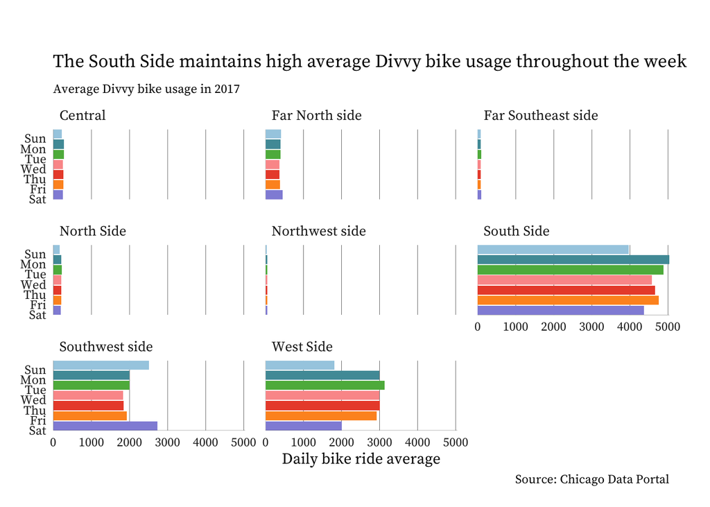

```r
divvy_c %>%
  filter(year(START.TIME) == c(2017)) %>%
  filter(!is.na(Community.Areas)) %>%
  mutate(WEEK.DAY = wday(START.TIME, label = TRUE),
         year = year(START.TIME),
         month = month(START.TIME),
         day = day(START.TIME)) %>%
  group_by(year, month, day, Chicago.side, WEEK.DAY, Chicago.side) %>%
  count() %>%
  group_by(WEEK.DAY, Chicago.side) %>%
  dplyr::summarise(MEAN.TRIP.NUM = mean(n)) %>%
  ggplot(aes(x = factor(WEEK.DAY,
                        levels = rev(levels(factor(WEEK.DAY)))),
             y = MEAN.TRIP.NUM, fill = WEEK.DAY)) +
  geom_col() +
  facet_wrap(~ Chicago.side) +
  coord_flip() +
  scale_fill_bikeshare(palette = "main") +
  labs(title = "The South Side maintains high average Divvy bike usage throughout the week",
    subtitle = "Average Divvy bike usage in 2017",
    caption = "Source: Chicago Data Portal",
    x = "Chicago Sides'",
    y = "Daily bike ride average") +
  scale_y_continuous(expand=c(0,0)) +
  scale_x_discrete(expand=c(0,0)) +
  bikeshare_style() +
  theme(legend.position="none",
        strip.text.x = element_text(size = 10),
        panel.margin = unit(1, "lines"),
        axis.title.y = element_blank(),
        plot.title = element_text(size=13, face="bold",
                                  margin = margin(10, 0, 10, 0)))
```

Two Community areas on the South Side - Fuller Park and Grand Boulevard - account for over 80% of rides in the area.

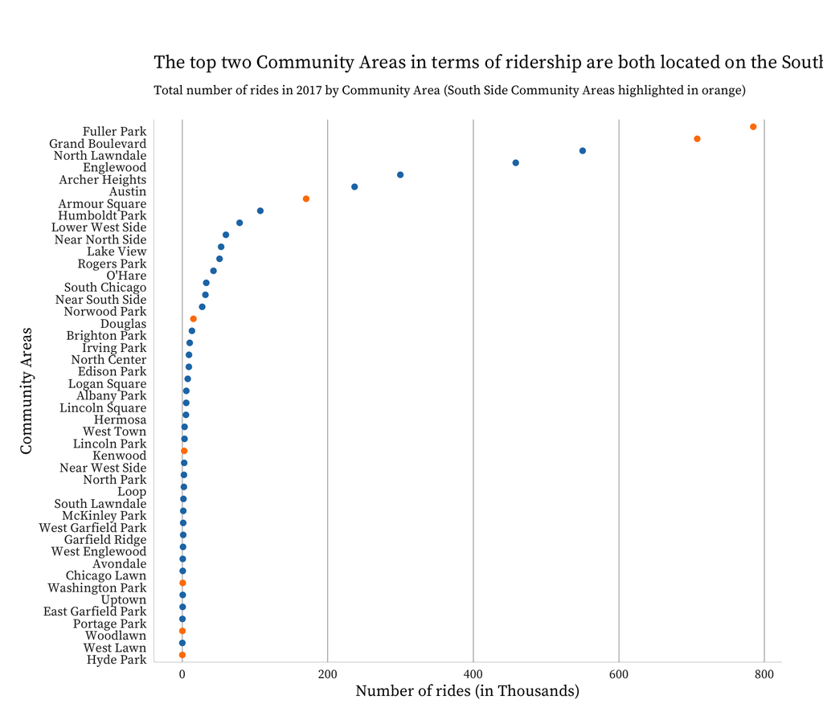

```r
divvy_c %>%
  filter(year(START.TIME) == c(2017)) %>%
  filter(!is.na(Community.Areas)) %>%
  group_by(Chicago.side, Community.Area.Name) %>%
  summarise(n_trips = n(),
            scaled_trips = n_trips/1000) %>%
  ggplot(aes(x = reorder(Community.Area.Name, scaled_trips), y = scaled_trips,
             color = ifelse(Chicago.side == "South Side", "fdbf6f", "black"))) +
  geom_point() +
  coord_flip() +
  bikeshare_style() +
  theme(legend.position = "none",
        plot.title = element_text(size=13, face="bold",
                                  margin = margin(10, 0, 10, 0))) +
  labs(title = "The top two Community Areas in terms of ridership are both located on the South Side of Chicago",
    subtitle = "Total number of rides in 2017 by Community Area (South Side Community Areas highlighted in orange)\n",
    x = "Community Areas",
    y = "Number of rides (in Thousands)") +
  scale_color_bikeshare(palette = "two_variables") +
  scale_y_continuous(labels = comma)
```

The first 30 minutes of bike rental time is free for annual members. Average trip duration is around 12 minutes Chicago-wide, with Community Areas falling both above and below the mean.

[figure not shown]

```r
# Global median time for trip duration in the city of chicago
# Median trip duration in Chicago is 11.46667   minutes
#divvy_c %>%
#  filter(!is.na(Community.Areas)) %>%
#  filter(year(START.TIME) == c(2017)) %>%
#  filter(!TRIP.DURATION > 86400) %>% # Filter out bikes classified as stolen
#  summarise(median_trip_duration = median(TRIP.DURATION)/60)

divvy_c %>%
  filter(!is.na(Community.Areas)) %>%
  filter(year(START.TIME) == c(2017)) %>%
  filter(!TRIP.DURATION > 86400) %>% # Filter out bikes classified as stolen (greater than 24 hours)
  group_by(Community.Area.Name, Chicago.side) %>%
  dplyr::summarise(median_time = median(TRIP.DURATION)/60) %>% # average trip by comm area in Minutes
  mutate(de_meaned_time = median_time - 11.45) %>%
  mutate(axis_color = ifelse(de_meaned_time > 0, "orange", "blue")) %>%
  ggplot(aes()) +
  geom_segment(aes(x = reorder(as.factor(Community.Area.Name), de_meaned_time),
                   xend = Community.Area.Name, y = 0,
                   yend = de_meaned_time, color = axis_color), size=1.3, alpha=0.9) +
  theme(legend.position = "none") +
  xlab("") +
  coord_flip() +
  bikeshare_style() +
  scale_y_continuous(expand=c(0,0), breaks = c(-4, -2, 0, 2, 4, 6, 8, 10, 12)) +
  scale_x_discrete(expand=c(0,0)) +
  labs(title = "Median Divvy bike rental time is 2 - 10 minutes higher than the \nCity wide median in many suburban areas",
    subtitle = "The median Divvy bike rental time Chicago-wide in 2017 was 11.45 minutes",
    caption = "Source: Chicago Data Portal",
    x = "Chicago Community Areas",
    y = "Minutes above and below Chicago's Median Divvy Rental Time")
```

[figure not shown]

```r
divvy_c %>%
  mutate(S_E_MATCH = ifelse(FROM.STATION.ID == TO.STATION.ID, 1, 0)) %>%
  group_by(Chicago.side) %>%
  summarise(total_rides = n(),
            n_se_same = sum(S_E_MATCH),
            per_se_same = (n_se_same/total_rides) * 100) %>%
  ggplot(aes(x = per_se_same, y = reorder(Chicago.side, per_se_same))) +
  geom_segment(aes(xend = 0, yend = Chicago.side)) +
  geom_point() +
  bikeshare_style() +
  scale_x_continuous(expand=c(0,0), breaks = c(0, 1, 2, 3, 4, 5, 6, 7, 8)) +
  labs(title = "The Far North and North Sides have the highest percentage \nof rides that begin and end at the same station",
 #   subtitle = "Average distance traveled by Divvy bikes per Chicago Side in 2018",
    caption = "Chicago Data Portal Divvy Trip Data",
    x = "% Rides that begin and end at the same station",
    y = "Chicago Sides")
```